# STA 141A: Assignment 1

Kyle Guanzon SID: 916279239

**Instructions** You may adapt the code in the course materials or any sources (e.g., the Internet, classmates, friends, generative AI). In fact, you can craft solutions for almost all questions from the course materials with minor modifications. However, you need to write up your own solutions and acknowledge all sources that you have cited in the Acknowledgement section.

Failing to acknowledge any non-original efforts will be counted as plagiarism. This incidence will be reported to the Student Judicial Affairs.

1. Explain data science in your own words. Imagine that your audience are your family members, friends, or anyone without any knowledge in related fields. References that might help craft an answer. More could be found by simply searching for “data science” on the Internet.
   - [ASA Statement on the Role of Statistics in Data Science](https://magazine.amstat.org/blog/2015/10/01/asa-statement-on-the-role-of-statistics-in-data-science/)
   - [Mission of Department of Statistics, UC Davis.](https://statistics.ucdavis.edu/mission)
   - [Statement by the UCD DataLab](https://datalab.ucdavis.edu/about/)
   - [Data science on Wikipedia](https://en.wikipedia.org/wiki/Data_science)

Data science is essentially taking information (or data), and deriving meaning from it. The study uses critical thinking and analaysis, intersected with statistics/programming, and a domain/field of study (politics, business, technology, etc.).

2. Please review the common tasks of data science in Chapter 1 of the course notes and identify your strengths in data science.

In particular, (i) describe the top two strengths (skills/characteristics/knowledge/…) of yours that apply to data science; I am skilled in ggplot() and data visualization tools to illustrate datasets.In domain knowledge, I am skilled in policy analysis, computer science (programming), retail and operations.

2. briefly review how you developed these strengths;  
   I was able to acquire data visualization skills through POL 51, and my Google Data Analytics Certificate Program. In my domain knowledge, I acquired my skills through work and school leadership experience.
3. explain how you plan to contribute to the final project with these strengths. Applying my skills to the final project, I would feel confident visualizing the data through graphs, and creating analyses based off of the illustrations.
3. Please review the common tasks of data science in Chapter 1 of the course notes and identify the task that you are least confident about.

In particular, please explain (i) what this task means with an example; The analysis task of a data scientist through statistical models, statistical theory, optimization, etc., is what I feel least confident about. Examples of this would be building statistical models to predict or analyze data.

2. why you feel least confident about this task; I feel least confident with theoretical and foundational statistics because this is my first few statistics classes I have taken in my education career, which is definitely an adjustment. In addition, I am only grasping the tip of the iceberg, and I have so much more to learn.
3. how you plan to improve your confidence. I would plan on utilizing office hours and TA hours to ask questions and clarify statistical concepts. I also plan on interacting and collaborating with my peers and network with them so I don’t feel left out.
4. Consider `81`,`170`,`1923`,`3825`.

```r
values <- c(81, 170, 1923, 3825) #creating vector
```

1. Check if they are divisible by `3` and `9`.

```r
# Code chunk obtained from ChatGPT
divisible_by_3 <- values %% 3 == 0 #checking if div by 3
divisible_by_9 <- values %% 9 == 0 #checking if div by 9

# Printing results
result <- data.frame(Number = values, Divisible_by_3 = divisible_by_3, Divisible_by_9 = divisible_by_9)
print(result)
```

```
##   Number Divisible_by_3 Divisible_by_9
## 1     81           TRUE           TRUE
## 2    170          FALSE          FALSE
## 3   1923           TRUE          FALSE
## 4   3825           TRUE           TRUE
```

2. Use integer division to calculate the sum of the digits of the numbers (e.g, the sum of the digits of `234` is `2+3+4=9`).

```r
# Code chunk obtained from ChatGPT
# Function to calculate the sum of digits
sum_of_digits <- function(n) {
  sum(n %/% 10^(0:(nchar(n)-1)) %% 10)
}

# Calculate the sum of digits for each number
sum_digits_result <- sapply(values, sum_of_digits)

# Print results
result <- data.frame(Number = values, Sum_of_Digits = sum_digits_result)
print(result)
```

```
##   Number Sum_of_Digits
## 1     81             9
## 2    170             8
## 3   1923            15
## 4   3825            18
```

3. Check whether these sums are divisible by `3` and `9`.

```r
# Code chunk obtained from ChatGPT
# Function to calculate the sum of digits
sum_of_digits <- function(n) {
  sum(n %/% 10^(0:(nchar(n)-1)) %% 10)
}

# Calculate the sum of digits for each number
sum_digits_result <- sapply(values, sum_of_digits)

# Check divisibility by 3 and 9
divisible_by_3 <- sum_digits_result %% 3 == 0
divisible_by_9 <- sum_digits_result %% 9 == 0

# Print results
result <- data.frame(Number = values, Sum_of_Digits = sum_digits_result, Divisible_by_3 = divisible_by_3, Divisible_by_9 = divisible_by_9)
print(result)
```

```
##   Number Sum_of_Digits Divisible_by_3 Divisible_by_9
## 1     81             9           TRUE           TRUE
## 2    170             8          FALSE          FALSE
## 3   1923            15           TRUE          FALSE
## 4   3825            18           TRUE           TRUE
```

4. State your observations from (i) and (iii) and verify your hypothesis on more numbers, if any.

*Information obtained from ChatGPT Two main observations are found, where: 1.) If the sum of digits of a number is divisible by 3, then the number itself is divisible by 3. 2.) Similarly, if the sumn of digits is divisible by 9, then the number itself is divisible by 9.

5. Read the help file for the `prod()` function.

```r
?prod()
```

1. Define `a <- c(2,4,6)`, `b <- c(1,3,5)`, `c <- c(3,5,7)`, use `a`,`b`,`c` and `prod()` to calculate
   $$2\cdot \left(\frac{2}{1}\cdot \frac{2}{3}\right) \left(\frac{4}{3}\cdot
   \frac{4}{5}\right)\left(\frac{6}{5}\cdot \frac{6}{7}\right).$$

```r
# Code chunk obtained from ChatGPT
# Generate vectors a, b, and c
a <- c(2, 4, 6)
b <- c(1, 3, 5)
c <- c(3, 5, 7)

result <- 2 * prod(a / b) * prod(a / c)

# Display the result
print(result)
```

```
## [1] 2.925714
```

2. Calculate
   $$2\cdot \left(\frac{2}{1}\cdot \frac{2}{3}\right) \left(\frac{4}{3}\cdot
   \frac{4}{5}\right)\cdots
   \left(\frac{1000}{999}\cdot \frac{1000}{1001}\right)$$

```r
# Code chunk obtained from ChatGPT
# Generate vectors a, b, and c
a <- seq(2, 1000, 2)
b <- seq(1, 999, 2)
c <- seq(3, 1001, 2)

# Calculate the result
result <- 2 * prod(a / b) * prod(b / c)

# Print the result
print(result)
```

```
## [1] 0.07920716
```

6. Write a function to calculate the following quantity for any given input $n$. Report the values (up to 6 [significant figures](https://en.wikipedia.org/wiki/Significant_figures) ) for $n=17, 91, 216$.

$$2\cdot \left(\frac{2}{1}\cdot \frac{2}{3}\right) \left(\frac{4}{3}\cdot
\frac{4}{5}\right)\cdots
\left(\frac{2n}{2n-1}\cdot \frac{2n}{2n+1}\right)$$

```r
# Code chunk obtained from ChatGPT
calculate_quantity <- function(n) {
  result <- 2

  for (i in 2:n) {
    result <- result * (2*i / (2*i - 1)) * (2*i / (2*i + 1))
  }

  return(result)
}

# Calculate and print the values for n = 17, 91, 216
n_values <- c(17, 91, 216)
results <- sapply(n_values, calculate_quantity)

# Display the results with 6 significant figures
results_rounded <- round(results, 6)
cat("For n =", n_values, ", the calculated values are:", results_rounded, "\n")
```

```
## For n = 17 91 216 , the calculated values are: 2.322778 2.349766 2.353475
```

7. Apply your function in (6) on $n=5,10, 15, \ldots, 500$. Draw a scatterplot between the outputs of your function versus the values of $n$s. State your findings, if any.

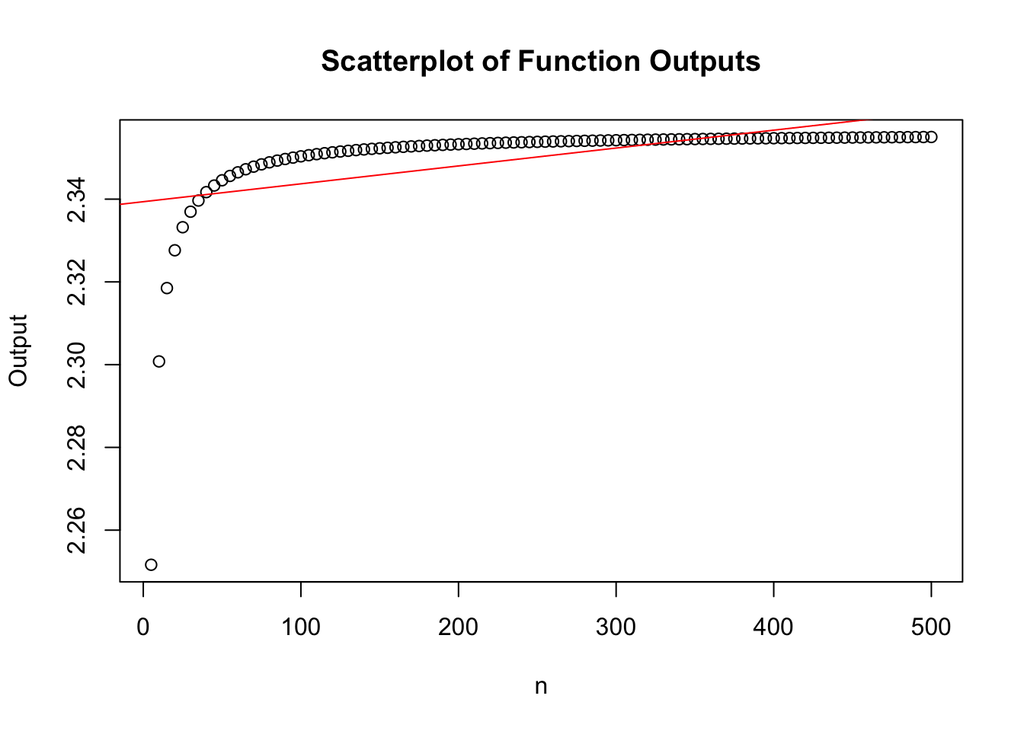

```r
# Code chunk obtained from ChatGPT
# Values of n from 5 to 500
new_values <- seq(5, 500, by = 5)

# Calculate the outputs for each value of n
output_values <- sapply(new_values, calculate_quantity)

# Create a scatterplot
plot(new_values, output_values, xlab = "n", ylab = "Output", main = "Scatterplot of Function Outputs")

# Add a trendline
fit <- lm(output_values ~ new_values)
abline(fit, col = "red")
```

8. For the rest of the problems, we will examine the `cars` dataset included in `R`. We can load `cars` with `data(cars)` if it is not in the workspace yet.

Ask `R` to report the first six observations in `cars`, and count how many observations and variables are in the dataset.

```r
data(cars)

# Code chunk obtained from ChatGPT
# Display the first six observations
first_six_observations <- head(cars)
print("First six observations:")
```

```
## [1] "First six observations:"
```

```r
print(first_six_observations)
```

```
##   speed dist
## 1     4    2
## 2     4   10
## 3     7    4
## 4     7   22
## 5     8   16
## 6     9   10
```

```r
# Count the number of observations and variables
num_observations <- nrow(cars)
num_variables <- ncol(cars)
print(paste("Number of observations:", num_observations))
```

```
## [1] "Number of observations: 50"
```

```r
print(paste("Number of variables:", num_variables))
```

```
## [1] "Number of variables: 2"
```

9. What does each column represent, and what is the meaning of their values?

From ?cars, we obtain the following information:

Column 1 represents the numeric Speed (mph) Column 2 represents the distance, the numeric Stopping distance (measured in feet)

10. What does each row represent?

Each row represents an observation on both variables speed and dist.

11. Create a scatterplot of variables in `cars`. Explain your observations on the scatter plot.

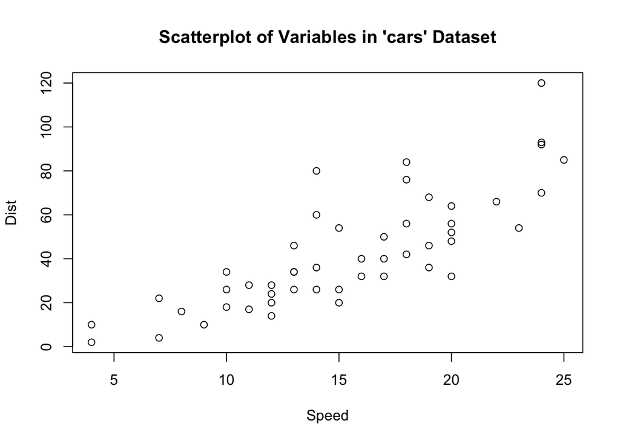

```r
# Code chunk obtained from ChatGPT
plot(cars, main = "Scatterplot of Variables in 'cars' Dataset", xlab = "Speed", ylab = "Dist")
```

## Acknowledgement

Failing to acknowledge any non-original efforts will be counted as plagiarism. This incidence will be reported to the Student Judicial Affairs.

If you use generative AI to solve any questions, please provide your instructions, conversations, and prompts here.

[output not shown]

[output not shown]

[output not shown]

[output not shown]